# Kaggle’s Titanic Competition

# Loading the libraries

```r
library(ggplot2)
library(data.table)
library(magrittr)
library(caret)
library(dplyr)
library(stringr)
library(knitr)
library(broom)
library(caret)
```

# About

I’ve joined this competition as my first one. My goal was to get to know a little bit more about machine learning and its difference from Econometrics. At this point, I have taken the Andrew Ng Coursera’s course and I have realized that the these two areas of knowledge have a lot in common. The most surprising was that I’ve alread had contact with more than 80% of the course’s content while working with Econometrics and Multivariate Analysis.

This Rnotebook has been produced few months ago. My rank today, 2019/10/26, is top 13%. I beleieve it’s not bad for a first contact to Machine Learning. The main point, for me, it is that I have learned a lot doing this competition!

# Loading the training and test datasets

The training dataset has 891 observations and 13 variables and the test dataset has 418 observations and 12 variables - the difference is due to the `Survived` variable in the former. These dataset were appended into a the new dataset `fullDT0` in order to facilitate the variable transformations such as transforming char type variable to a factor one. Hence, this dataset has 1309 observation and 13 variables.

```r
b.test0 <- data.table(read.csv(paste(getwd(),"/datasets/", "test.csv", sep = ""), na.strings = c("")))[, Origin := "test"]
b.train0 <- data.table(read.csv(paste(getwd(),"/datasets/", "train.csv", sep = ""), na.strings = c("")))[, Origin := "train"]
fullDT0 <- rbind(b.test0, b.train0, fill = TRUE, use.names = TRUE)
lapply(list(b.train0, b.test0, fullDT0), dim)
```

```
## [[1]]
## [1] 891  13
##
## [[2]]
## [1] 418  12
##
## [[3]]
## [1] 1309   13
```

# Checking the variables type and choosing the a new one properly.

In this section, the variables type is changed for better usage in the modelling.

```r
str(fullDT0)
```

```
## Classes 'data.table' and 'data.frame':   1309 obs. of  13 variables:
##  $ PassengerId: int  892 893 894 895 896 897 898 899 900 901 ...
##  $ Pclass     : int  3 3 2 3 3 3 3 2 3 3 ...
##  $ Name       : Factor w/ 1307 levels "Abbott, Master. Eugene Joseph",..: 210 409 273 414 182 370 85 58 5 104 ...
##  $ Sex        : Factor w/ 2 levels "female","male": 2 1 2 2 1 2 1 2 1 2 ...
##  $ Age        : num  34.5 47 62 27 22 14 30 26 18 21 ...
##  $ SibSp      : int  0 1 0 0 1 0 0 1 0 2 ...
##  $ Parch      : int  0 0 0 0 1 0 0 1 0 0 ...
##  $ Ticket     : Factor w/ 929 levels "110469","110489",..: 153 222 74 148 139 262 159 85 101 270 ...
##  $ Fare       : num  7.83 7 9.69 8.66 12.29 ...
##  $ Cabin      : Factor w/ 186 levels "A11","A18","A21",..: NA NA NA NA NA NA NA NA NA NA ...
##  $ Embarked   : Factor w/ 3 levels "C","Q","S": 2 3 2 3 3 3 2 3 1 3 ...
##  $ Origin     : chr  "test" "test" "test" "test" ...
##  $ Survived   : int  NA NA NA NA NA NA NA NA NA NA ...
##  - attr(*, ".internal.selfref")=<externalptr>
```

The variables `PassengerId`, `PClass`, `Name` and `Ticket` are st as integer, factor and factor, respectively. `PassengerId` is turned into character variable, `PClass` is changed to *factor* because it has an ordinal meaning (with 3rd class the lowest), while `Name` and `Ticket` are transformed from *factor* to *character* they are similar to a passenger identification. It could exist more than one passenger with the same name and the same ticket identification, however the number of factor levels they have suggests the variables themself would not be a source of significant information for the model. `Survived` is also modified to *factor* because is a binary situation: it equals 1 if the person has survived, otherwise it equals 0.

```r
fullDT0$PassengerId %<>% as.character()
fullDT0$Pclass %<>% factor(levels = c(3, 2, 1))
fullDT0$Name %<>% as.character()
fullDT0$Ticket %<>% as.character()
fullDT0$Survived %<>% factor()
```

## Feature engineering - creating new variables that may be useful while modelling

### Family size

It seems reasonable to me that bigger families are more dificult to save than those with fewer members.

```r
fullDT0[, Family.S := SibSp + Parch + 1]
summary(fullDT0$Family.S)
```

```
##    Min. 1st Qu.  Median    Mean 3rd Qu.    Max.
##   1.000   1.000   1.000   1.884   2.000  11.000
```

### Titles

*I’ve read about this feature doing some googling.* The idea here is that Title could be a proxy for social status and wealth. It is well known that social status may make a big difference in social interactions. In other words, the better the status, the higher the preference in the saving queue.

# EXPLORATORY DATA ANALYSIS

The goal of this topic is getting familiar with the dataset in order to identify some issue that has to be dealt with and also discover some interesting pattern among the variables, or even some discrepant fact.

It is displayed in the summary that the variables `Age`, `Fare`, `Cabin` and `Embarked` have missing values. Missing values are a sort of concern because only complete observations are taken into account when running any sort of regression. One way of dealing with *NAs* is dropping observation that has it. As a result, the number of available observations could drop in a considerable amount. The problem of doing this is that it could bring bias to the parameters because the sample may no longer represent the population. Another possibility is imputation. There are several methods of doing so: mean/median imputation and regression imputation, among others.

Almost 80% of the observations of `Cabin` are missing values. Doing any imputation in this high amount of observation could bring a lot of uncertainty to the model. Hence, it will not be used for the predicting task.

```r
summary(fullDT0)
```

```
##  PassengerId        Pclass      Name               Sex
##  Length:1309        3:709   Length:1309        female:466
##  Class :character   2:277   Class :character   male  :843
##  Mode  :character   1:323   Mode  :character
##
##
##
##
##       Age            SibSp            Parch          Ticket
##  Min.   : 0.17   Min.   :0.0000   Min.   :0.000   Length:1309
##  1st Qu.:21.00   1st Qu.:0.0000   1st Qu.:0.000   Class :character
##  Median :28.00   Median :0.0000   Median :0.000   Mode  :character
##  Mean   :29.88   Mean   :0.4989   Mean   :0.385
##  3rd Qu.:39.00   3rd Qu.:1.0000   3rd Qu.:0.000
##  Max.   :80.00   Max.   :8.0000   Max.   :9.000
##  NA's   :263
##       Fare                     Cabin      Embarked      Origin
##  Min.   :  0.000   C23 C25 C27    :   6   C   :270   Length:1309
##  1st Qu.:  7.896   B57 B59 B63 B66:   5   Q   :123   Class :character
##  Median : 14.454   G6             :   5   S   :914   Mode  :character
##  Mean   : 33.295   C22 C26        :   4   NA's:  2
##  3rd Qu.: 31.275   C78            :   4
##  Max.   :512.329   (Other)        : 271
##  NA's   :1         NA's           :1014
##  Survived      Family.S          Title
##  0   :549   Min.   : 1.000   Master.: 61
##  1   :342   1st Qu.: 1.000   Miss.  :260
##  NA's:418   Median : 1.000   Mr.    :757
##             Mean   : 1.884   Mrs.   :197
##             3rd Qu.: 2.000   Raro   : 34
##             Max.   :11.000
##
```

```r
fullDT0 <- fullDT0[, Cabin := NULL]
```

## Variable `Survived`

Major part of the the passengers did not survived. What it is important here is the fact that this variable could be considered as balanced, there is no concentration of observations in one single class.

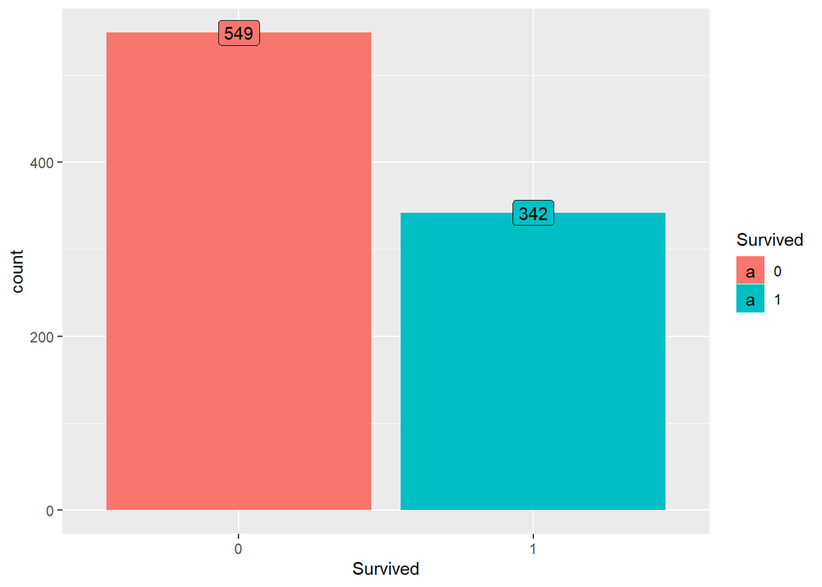

```r
ggplot(data = fullDT0[fullDT0$Origin == "train", ], aes(x = Survived, fill = Survived)) + geom_bar(stat = "count") +
  geom_label(stat = "count", aes(label = ..count..))
```

## Variable `Pclass`

It is seems that there is a relation between the `Pclass` and `Survived`. Despite beeing in the 2nd class may appear that it does not matter much whether the passenger is going to survive, being in the 1st or 3rd class matter a lot!

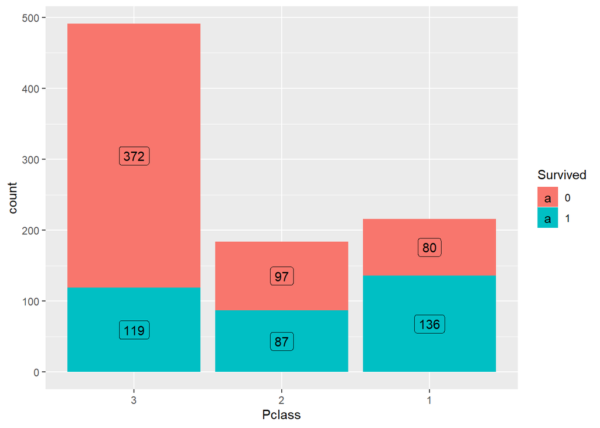

```r
ggplot(data = fullDT0[fullDT0$Origin == "train", ], aes(x = Pclass, fill = Survived), na.rm = TRUE) + geom_bar(stat = "count") +
  geom_label(stat = "count", aes(label = stat(count)), position = position_stack(vjust = 0.5))
```

## Variable `Sex`

It is showed in the graph that being a female migth contribute strongly to the chances of beeing alive after the disaster. 74% of the females survived, meanwhile about 80% of the men died.

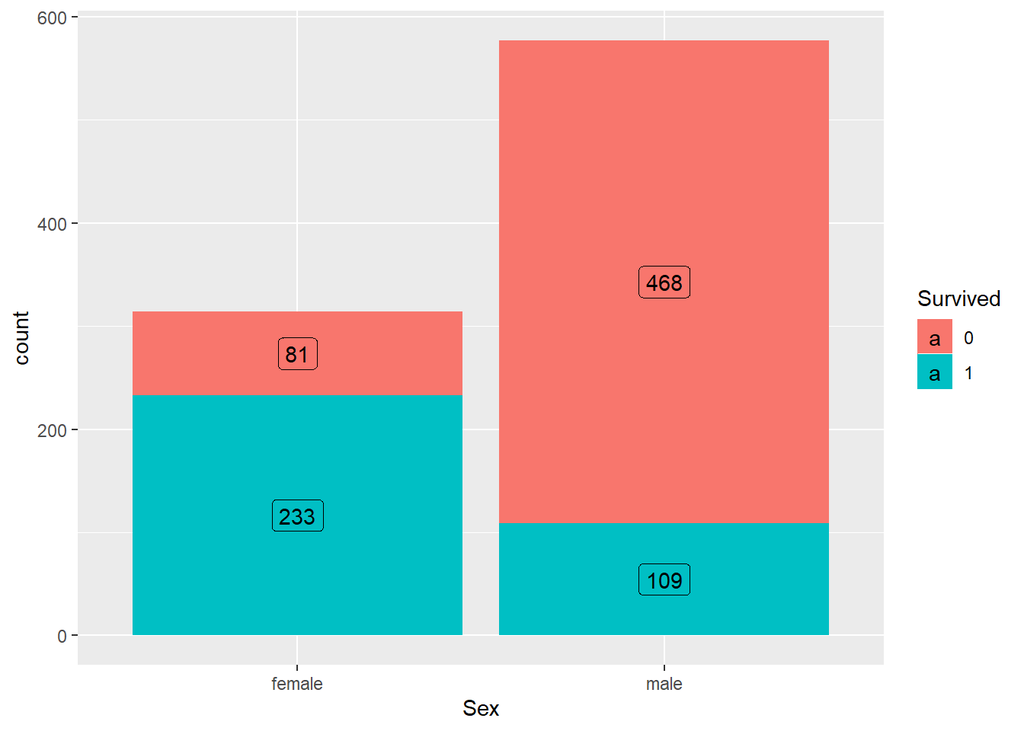

```r
ggplot(data = fullDT0[fullDT0$Origin == "train", ], aes(x = Sex, fill = Survived), na.rm = TRUE) +
  geom_bar(stat = "count") + geom_label(stat = "count", aes(label = stat(count)), position = position_stack(vjust = 0.5))
```

### Variable `SibSp`

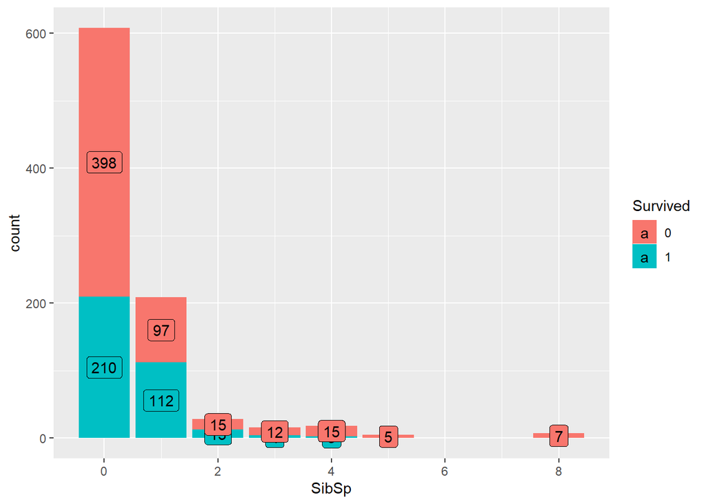

```r
ggplot(data = fullDT0[fullDT0$Origin == "train", ], aes(x = SibSp, fill = Survived), na.rm = TRUE) + geom_bar(stat = "count") + geom_label(stat = "count", aes(label = stat(count)), position = position_stack(vjust = 0.5))
```

```r
  cbind(round(prop.table(rbind(table(fullDT0$SibSp, fullDT0$Survived), colSums(table(fullDT0$SibSp, fullDT0$Survived))), margin = 1)*100, 1),
        rowSums(round(prop.table(rbind(table(fullDT0$SibSp, fullDT0$Survived), colSums(table(fullDT0$SibSp, fullDT0$Survived))), margin = 1)*100, 1))) %>% `colnames<-`(c("Not Survived", "Survived", "Total")) %>% `rownames<-`(c(0:5, 8, "Total"))
```

```
##       Not Survived Survived Total
## 0             65.5     34.5   100
## 1             46.4     53.6   100
## 2             53.6     46.4   100
## 3             75.0     25.0   100
## 4             83.3     16.7   100
## 5            100.0      0.0   100
## 8            100.0      0.0   100
## Total         61.6     38.4   100
```

## Variable `Parch`

The same observation about `SibSp` can be made for `Parch`. This could be a problem in the regression because they present the same pattern. Making a combination of both could be something to consider when feature engeneering.

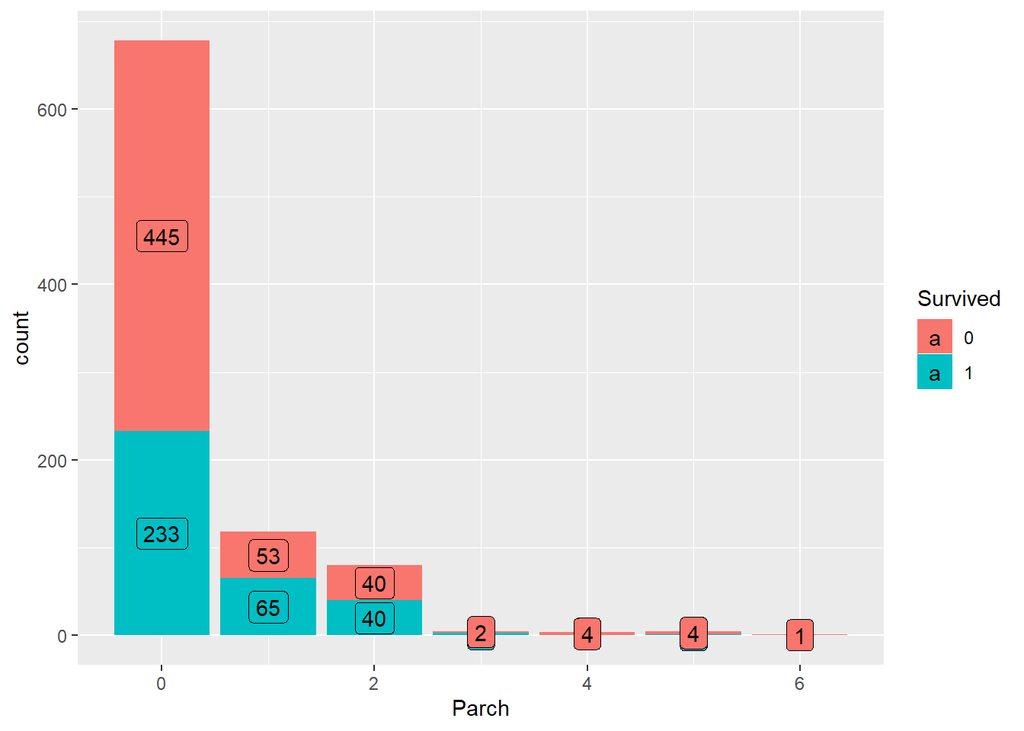

```r
ggplot(data = fullDT0[fullDT0$Origin == "train", ], aes(x = Parch, fill = Survived), na.rm = TRUE) + geom_bar(stat = "count") + geom_label(stat = "count", aes(label = stat(count)), position = position_stack(vjust = 0.5))
```

```r
cbind(round(prop.table(rbind(table(fullDT0$Parch, fullDT0$Survived), colSums(table(fullDT0$Parch, fullDT0$Survived))), margin = 1)*100, 1),
      rowSums(round(prop.table(rbind(table(fullDT0$Parch, fullDT0$Survived), colSums(table(fullDT0$Parch, fullDT0$Survived))), margin = 1)*100, 1))) %>%
  `colnames<-`(c("Not Survived", "Survived", "Total")) %>% `rownames<-`(c(0:6, 9, "Total"))
```

```
##       Not Survived Survived Total
## 0             65.6     34.4   100
## 1             44.9     55.1   100
## 2             50.0     50.0   100
## 3             40.0     60.0   100
## 4            100.0      0.0   100
## 5             80.0     20.0   100
## 6            100.0      0.0   100
## 9              NaN      NaN   NaN
## Total         61.6     38.4   100
```

## Variable `Fare`

### Missing value on `Fare`

As shown in the summary, `Fare` presents a single missing value. This matter is taken care of before doing the analysis.

```r
fullDT0[which(is.na(fullDT0$Fare)),] %>% kable()
```

| PassengerId | Pclass | Name | Sex | Age | SibSp | Parch | Ticket | Fare | Embarked | Origin | Survived | Family.S | Title |
| --- | --- | --- | --- | --- | --- | --- | --- | --- | --- | --- | --- | --- | --- |
| 1044 | 3 | Storey, Mr. Thomas | male | 60.5 | 0 | 0 | 3701 | NA | S | test | NA | 1 | Mr. |

The next step consist in searching for some pattern that would make its value imputation possible. First, it has been looked up people with the same family name, which is inexistant. Then, it has been search for someone who has the same `Ticket`, meaning she could be a relative or friend who was travelling together - no match. Finally, from the idea that people with the same departure (`Embarked = S`), the same class (`Pclass = 3` and the same *ticket*’s number pattern - with 4 digits - migth have similar attributes (`Fare`) of Mr. Tomas’.

```r
fullDT0[which(grepl("^Storey", fullDT0$Name)), ] %>% kable()
```

| PassengerId | Pclass | Name | Sex | Age | SibSp | Parch | Ticket | Fare | Embarked | Origin | Survived | Family.S | Title |
| --- | --- | --- | --- | --- | --- | --- | --- | --- | --- | --- | --- | --- | --- |
| 1044 | 3 | Storey, Mr. Thomas | male | 60.5 | 0 | 0 | 3701 | NA | S | test | NA | 1 | Mr. |

```r
fullDT0[which(grepl("3701", fullDT0$Ticket)), ] %>% kable()
```

| PassengerId | Pclass | Name | Sex | Age | SibSp | Parch | Ticket | Fare | Embarked | Origin | Survived | Family.S | Title |
| --- | --- | --- | --- | --- | --- | --- | --- | --- | --- | --- | --- | --- | --- |
| 1044 | 3 | Storey, Mr. Thomas | male | 60.5 | 0 | 0 | 3701 | NA | S | test | NA | 1 | Mr. |
| 1176 | 3 | Rosblom, Miss. Salli Helena | female | 2.0 | 1 | 1 | 370129 | 20.2125 | S | test | NA | 3 | Miss. |
| 255 | 3 | Rosblom, Mrs. Viktor (Helena Wilhelmina) | female | 41.0 | 0 | 2 | 370129 | 20.2125 | S | train | 0 | 3 | Mrs. |
| 425 | 3 | Rosblom, Mr. Viktor Richard | male | 18.0 | 1 | 1 | 370129 | 20.2125 | S | train | 0 | 3 | Mr. |

```r
fullDT0[which(nchar(fullDT0$Ticket) == 4 &  fullDT0$Embarked == "S" & fullDT0$Pclass == 3), ][order(Ticket)][1:5, ] %>% kable()
```

| PassengerId | Pclass | Name | Sex | Age | SibSp | Parch | Ticket | Fare | Embarked | Origin | Survived | Family.S | Title |
| --- | --- | --- | --- | --- | --- | --- | --- | --- | --- | --- | --- | --- | --- |
| 1249 | 3 | Lockyer, Mr. Edward | male | NA | 0 | 0 | 1222 | 7.8792 | S | test | NA | 1 | Mr. |
| 931 | 3 | Hee, Mr. Ling | male | NA | 0 | 0 | 1601 | 56.4958 | S | test | NA | 1 | Mr. |
| 75 | 3 | Bing, Mr. Lee | male | 32 | 0 | 0 | 1601 | 56.4958 | S | train | 1 | 1 | Mr. |
| 170 | 3 | Ling, Mr. Lee | male | 28 | 0 | 0 | 1601 | 56.4958 | S | train | 0 | 1 | Mr. |
| 510 | 3 | Lang, Mr. Fang | male | 26 | 0 | 0 | 1601 | 56.4958 | S | train | 1 | 1 | Mr. |

It seems that high fare *tickets* are those which have repeated occurencies. Therefore, because Mr. Thomas’ ticket number is unique, the missing value under analysis is imputated by the mean of the subset of unique ticketnumbers that follow the conditions discribed (`mean` = *10.85302* ).

```r
fullDT0[which(is.na(fullDT0$Fare)), "Fare"] <- fullDT0[which(nchar(fullDT0$Ticket) == 4 &  fullDT0$Embarked == "S" & fullDT0$Pclass == 3), ][ !duplicated(Ticket), mean(Fare, na.rm = TRUE)]
```

### Plotting `Fare`

Looking at the histogram that the `Fare`s values, one could see that fare values are concentrated up to 100 and values bigger than 250 might be considered as high leverage

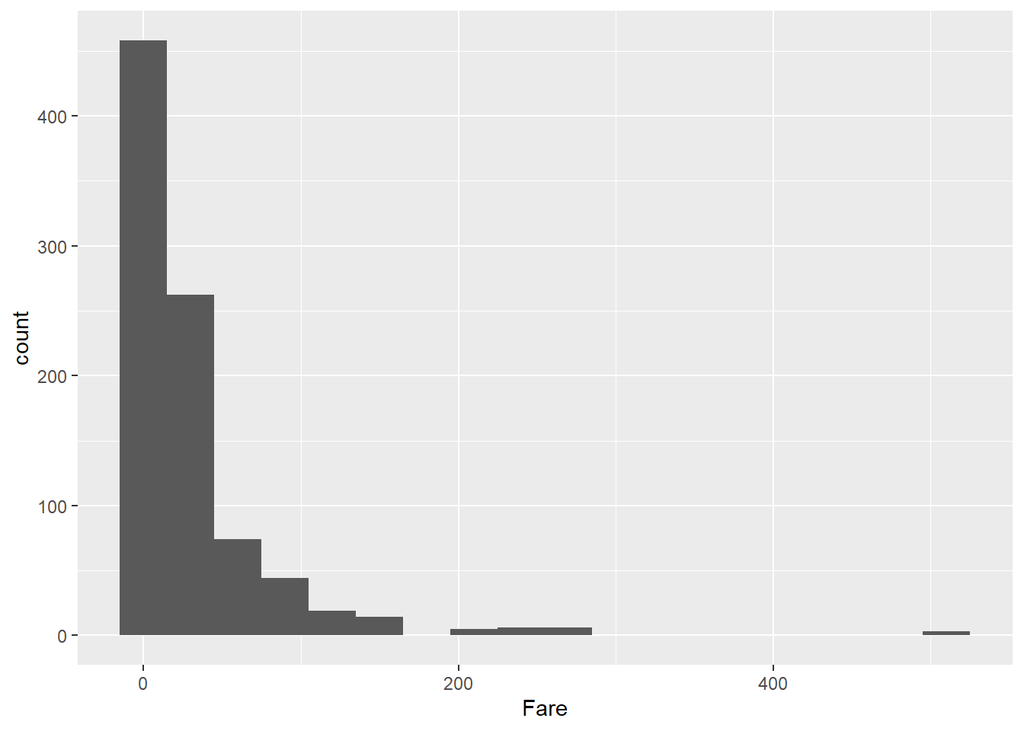

```r
ggplot(data = fullDT0[fullDT0$Origin == "train", ], aes(x = Fare)) + geom_histogram(binwidth = 30)
```

## Variable `Embarked`

### Missing values on `Embarked`

While listing the missing variables, it can be seen that there are only two.

```r
fullDT0[which(is.na(fullDT0$Embarked)),] %>% kable()
```

| PassengerId | Pclass | Name | Sex | Age | SibSp | Parch | Ticket | Fare | Embarked | Origin | Survived | Family.S | Title |
| --- | --- | --- | --- | --- | --- | --- | --- | --- | --- | --- | --- | --- | --- |
| 62 | 1 | Icard, Miss. Amelie | female | 38 | 0 | 0 | 113572 | 80 | NA | train | 1 | 1 | Miss. |
| 830 | 1 | Stone, Mrs. George Nelson (Martha Evelyn) | female | 62 | 0 | 0 | 113572 | 80 | NA | train | 1 | 1 | Mrs. |

On the same line of thought of the previous analysis, it is noticeable that there is no other passenger with the same surname of these two observations in analysis. Then they are compared with passengers that also belong to first class (`Pclass == 1`) and have the *ticket* starting with *113*. It is noteworthy on the Box-plot chart that the ticket fare that are equal to 80 (`Fare == 80`), red line in the chart, might be an outlier `Embarked == S`. Therefore, those two missing values are set as *C* .

```r
fullDT0[which(grepl("^Icard", fullDT0$Name)), ] %>% kable()
```

| PassengerId | Pclass | Name | Sex | Age | SibSp | Parch | Ticket | Fare | Embarked | Origin | Survived | Family.S | Title |
| --- | --- | --- | --- | --- | --- | --- | --- | --- | --- | --- | --- | --- | --- |
| 62 | 1 | Icard, Miss. Amelie | female | 38 | 0 | 0 | 113572 | 80 | NA | train | 1 | 1 | Miss. |

```r
fullDT0[which(grepl("^Stone", fullDT0$Name)), ]%>% kable()
```

| PassengerId | Pclass | Name | Sex | Age | SibSp | Parch | Ticket | Fare | Embarked | Origin | Survived | Family.S | Title |
| --- | --- | --- | --- | --- | --- | --- | --- | --- | --- | --- | --- | --- | --- |
| 830 | 1 | Stone, Mrs. George Nelson (Martha Evelyn) | female | 62 | 0 | 0 | 113572 | 80 | NA | train | 1 | 1 | Mrs. |

```r
fullDT0[which(grepl("^113", fullDT0$Ticket)), ][order(Ticket)][1:5, ] %>% kable()
```

| PassengerId | Pclass | Name | Sex | Age | SibSp | Parch | Ticket | Fare | Embarked | Origin | Survived | Family.S | Title |
| --- | --- | --- | --- | --- | --- | --- | --- | --- | --- | --- | --- | --- | --- |
| 712 | 1 | Klaber, Mr. Herman | male | NA | 0 | 0 | 113028 | 26.55 | S | train | 0 | 1 | Mr. |
| 1107 | 1 | Head, Mr. Christopher | male | 42.0 | 0 | 0 | 113038 | 42.50 | S | test | NA | 1 | Mr. |
| 332 | 1 | Partner, Mr. Austen | male | 45.5 | 0 | 0 | 113043 | 28.50 | S | train | 0 | 1 | Mr. |
| 1247 | 1 | Julian, Mr. Henry Forbes | male | 50.0 | 0 | 0 | 113044 | 26.00 | S | test | NA | 1 | Mr. |
| 537 | 1 | Butt, Major. Archibald Willingham | male | 45.0 | 0 | 0 | 113050 | 26.55 | S | train | 0 | 1 | Raro |

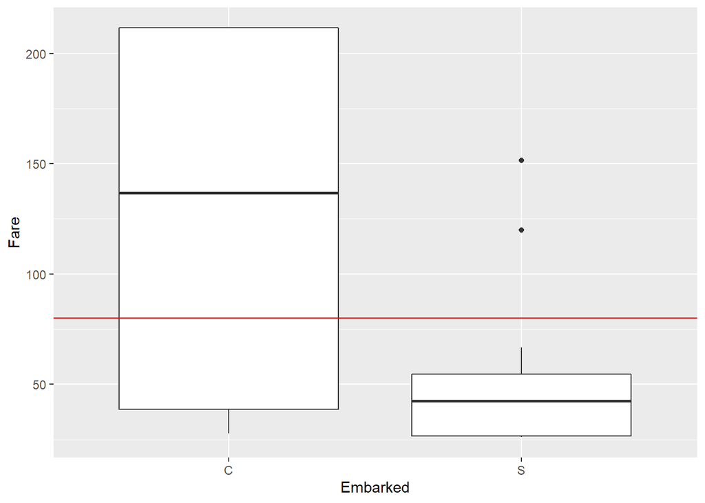

```r
ggplot(fullDT0[which(grepl("^113", fullDT0$Ticket) & fullDT0$Pclass == 1 & !is.na(fullDT0$Embarked)) , ], aes(x = Embarked, y = Fare))  + geom_boxplot() + geom_hline(yintercept = 80, color = "Red")
```

```r
fullDT0[which(is.na(fullDT0$Embarked)), "Embarked"] <- "C"
```

### Vriable `Age`

There are 263 missing values for the variable `Age`. As we can see in the Box Plot chart, the variable presents different patterns among the `Pclass`

```r
summary(fullDT0$Age)
```

```
##    Min. 1st Qu.  Median    Mean 3rd Qu.    Max.    NA's
##    0.17   21.00   28.00   29.88   39.00   80.00     263
```

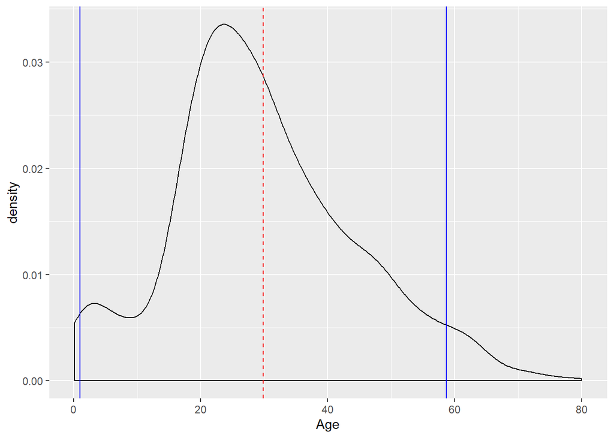

```r
ggplot(fullDT0, aes(x = Age)) + geom_density() + geom_vline(aes(xintercept = mean(Age, na.rm = TRUE)), color = "red", linetype = "dashed") + geom_vline(aes(xintercept = mean(Age, na.rm = TRUE) + 2*sd(Age, na.rm = TRUE)), color = "blue") + geom_vline(aes(xintercept = mean(Age, na.rm = TRUE) - 2*sd(Age, na.rm = TRUE)), color = "blue")
```

It is noticeable, in the Box-Plot chart, that there are different patterns of age distribution among `Pclass`. The same can be said when analysing `Age` among `Title`.

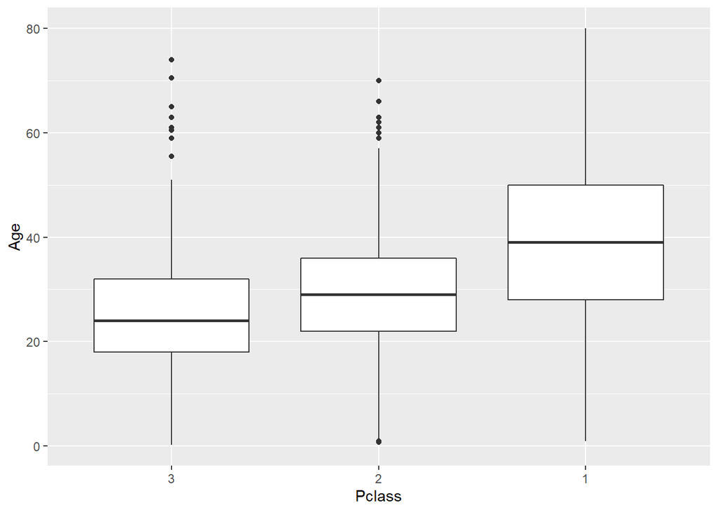

```r
ggplot(fullDT0, aes(x = Pclass, y = Age), na.rm = TRUE) + geom_boxplot()
```

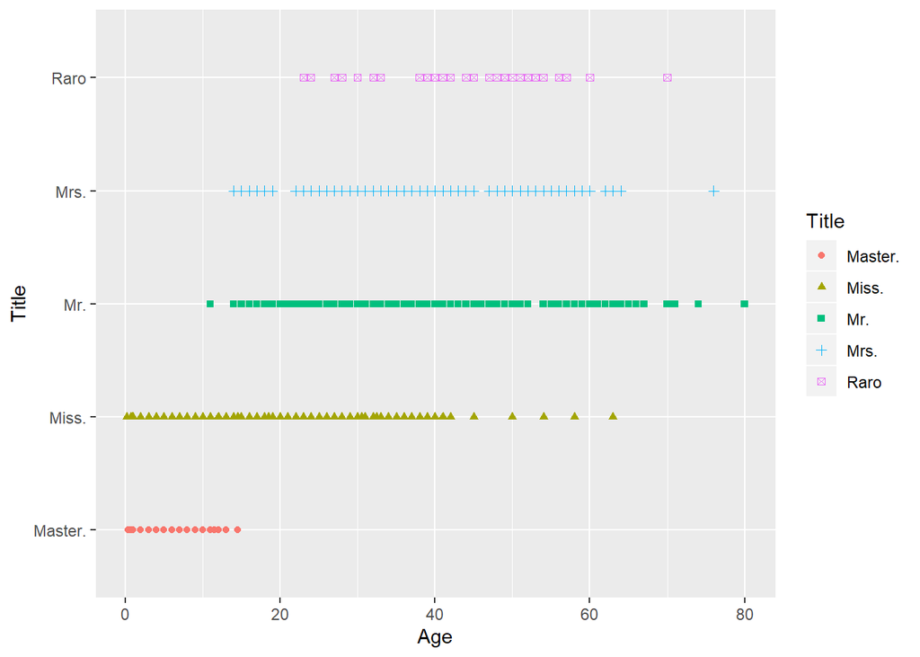

```r
ggplot(data = fullDT0, mapping = aes(x = Age, y = Title, shape = Title, color = Title)) + geom_point()
```

#### Identifying `Age` ouliers

One possible way of dealing with outliers in the dataset is, instead of deleting, to flag them with a dummy in the model.

```r
outliergeral <-  boxplot.stats(fullDT0$Age)$out
outlierP1 <- boxplot.stats(fullDT0$Age[fullDT0$Pclass == 1])$out
outlierP2 <- boxplot.stats(fullDT0$Age[fullDT0$Pclass == 2])$out
outlierP3 <- boxplot.stats(fullDT0$Age[fullDT0$Pclass == 3])$out
fullDT0[, OutlierAge := ifelse(Age %in% outliergeral, 1, 0)]
```

#### Prediction of `Age` missing values

Instead of deleting observations that present missing value, one powerfull alternative is using a statistical model to predict the missing value with respect of the remaning characteristics present in the dataset.

Creating the training and test sets

```r
set.seed(42)
ageFull <- fullDT0[!is.na(fullDT0$Age), -"Survived"]
age.trainIndex <- createDataPartition(ageFull$Age, p = .75, list = FALSE, times = 1)
ageTrain <-ageFull[age.trainIndex]
ageTest <- ageFull[-age.trainIndex]
```

```r
set.seed(3500)
# OLS with intercept
ols.Age <- train(Age ~ Pclass + Sex + SibSp + Parch + Fare + Embarked + Title + OutlierAge, data = ageTrain,
                 trControl = trainControl(method = "cv"), verboseIter = TRUE, method = "lm", tuneGrid = expand.grid(intercept = TRUE))
ageTest[, pAge.ols := predict(ols.Age, newdata = ageTest, type = "raw")]
accuracy.Age <- list("ols" = postResample(pred = ageTest$pAge.ols, obs = ageTest$Age))

# OLS with no intercept
ols0.Age <- train(Age ~ Pclass + Sex + SibSp + Parch + Fare + Embarked + Title + OutlierAge, data = ageTrain,
                 trControl = trainControl(method = "cv"), verboseIter = TRUE, method = "lm", tuneGrid = expand.grid(intercept = FALSE))
ageTest[, pAge.ols0 := predict(ols0.Age, newdata = ageTest, type = "raw")]
accuracy.Age$ols.nIntercp <- postResample(pred = ageTest$pAge.ols0, obs = ageTest$Age)

#Linear Stepwise Regression
step.Age <- train(Age ~ Pclass + Sex + SibSp + Parch + Fare + Embarked + Title + OutlierAge, data = ageTrain, method = "glmStepAIC",
                  trControl = trainControl(method = "cv"))
ageTest[, pAge.step := predict(step.Age, newdata = ageTest, type = "raw")]
accuracy.Age$stepwise <- postResample(pred = ageTest$pAge.step, obs = ageTest$Age)

accuracy.Age
```

[output not shown]

I diced to use the results of the Stepwise Regression by its lower errors.

```r
fullDT0[, Age.step := ifelse(is.na(fullDT0$Age), predict(step.Age, newdata = fullDT0, type = "raw"), Age)]
```

# Modelling and estimating the Survived variable

Separating the training and test dataset, with respect to original observations from Kaggle.

```r
set.seed(875614)
b.train.1 <- fullDT0[fullDT0$Origin == "train"]
b.totalTrainIndex <- createDataPartition(b.train.1$Survived, p = 0.75, list = FALSE, times = 1)
b.totalTrain <- b.train.1[b.totalTrainIndex]
b.totalTest <- b.train.1[-b.totalTrainIndex]
```

The following methods were used for estimating the `Survived` variable: Logistic Regression, Logistic Regression with Stepwise, Logistic Regression with Boosting and Support Vector Machine,

```r
#Logistic regression
logit <- train(Survived ~ Pclass + Sex + Age.step + SibSp + Parch + Family.S + Fare + Embarked + Title,
               data = b.totalTrain, method = "glm", family = binomial(link = "logit"), trControl = trainControl(method = "cv"))
b.totalTest[, Survived1 := predict(logit, newdata = b.totalTest, type = "raw")]
modelsSummary <- list(logit = postResample(pred = b.totalTest$Survived1, obs = b.totalTest$Survived))
confusionMatrix(data = b.totalTest$Survived1, reference = b.totalTest$Survived)
varImp(logit)

# Logistic Regression, identifying outlier observations for Age
logitOutlier <- train(Survived ~ Pclass + Sex + Age.step + Age.step*OutlierAge + SibSp + Parch + Family.S + Fare + Embarked + Title,
                      data = b.totalTrain, method = "glm", family = binomial(link = "logit"), trControl = trainControl(method = "cv"))
b.totalTest[, Survived2 := predict(logitOutlier, newdata = b.totalTest, type = "raw")]
modelsSummary$logitOutlier <- postResample(pred = b.totalTest$Survived2, obs = b.totalTest$Survived)
confusionMatrix(data = b.totalTest$Survived2, reference = b.totalTest$Survived)
varImp(logitOutlier)

# Logistic Regression with Stepwise - here, I added the Age^2 because the death rate in the upper bound and lower bound was higher.
logitstep <- step(glm(Survived ~ 1, data = b.totalTrain, family = "binomial"),
                  scope = list(
                    lower = glm(Survived ~ 1, data = b.totalTrain, family = "binomial"),
                    upper = glm(Survived ~ Pclass + Sex + Age.step + I(Age.step^2) + Age.step*OutlierAge + SibSp + Parch + Family.S +
                                  Fare + Embarked + Title + Pclass*Sex + Pclass*Sex*Age.step + Sex*Age.step + Sex*Family.S +
                                  Age*Family.S + Sex*Age*Family.S, data = b.totalTrain, family = "binomial")), direction = "forward")
b.totalTest[, SruvivedStep := ifelse(predict(logitstep, newdata = b.totalTest, type = "response") > 0.5, 1, 0)]
modelsSummary$logitStep <- postResample(pred = b.totalTest$SruvivedStep, obs = b.totalTest$Survived)

# Support Vector Machine
svm <- train(Survived ~ Pclass + Sex + Age.step + SibSp + Parch + Family.S + Fare + Embarked + Title, data = b.totalTrain, method = "svmRadial",
             trControl = trainControl(method = "cv"), tuneLength = 10)
b.totalTest[, SurvivedSVM := predict(svm, newdata = b.totalTest, type = "raw")]
modelsSummary$svm <- postResample(pred = b.totalTest$SurvivedSVM, obs = b.totalTest$Survived)

#SVM with the outlier Age flagged
svmOutlier <- train(Survived ~ Pclass + Sex + Age.step + Age.step*OutlierAge + SibSp + Parch + Family.S + Fare + Embarked + Title,
             data = b.totalTrain, method = "svmRadial", trControl = trainControl(method = "cv"), tuneLength = 10)
b.totalTest[, SurvivedSVMOut := predict(svmOutlier, newdata = b.totalTest, type = "raw")]
modelsSummary$svmOut <- postResample(pred = b.totalTest$SurvivedSVMOut, obs = b.totalTest$Survived)

# SVM with some variable interactions that I believe make sens, by data exploration - best result in Kaggle
svm2 <- train(Survived ~ Pclass*Sex + Sex + Age.step + Sex*Age.step + OutlierAge + Family.S + Fare + Embarked + Title,
              data = b.totalTrain, method = "svmRadial", trControl = trainControl(method = "repeatedcv", number = 10, repeats = 3), tuneLength = 15)
b.totalTest[, SurvivedSVM2 := predict(svm2, newdata = b.totalTest, type = "raw")]
modelsSummary$svm2 <- postResample(pred = b.totalTest$SurvivedSVM2, obs = b.totalTest$Survived)
confusionMatrix(b.totalTest$Survived, b.totalTest$SurvivedSVM2)

# SVM with some variable interactions that I believe make sens, by data exploration, and Age outliers flagged
svm2outlier <- train(Survived ~ Pclass*Sex + Sex + Age.step + Sex*Age.step + OutlierAge*Age.step + Family.S + Fare + Embarked + Title,
              data = b.totalTrain, method = "svmRadial", trControl = trainControl(method = "cv"), tuneLength = 10)
b.totalTest[, SurvivedSVM2out := predict(svm2outlier, newdata = b.totalTest, type = "raw")]
modelsSummary$svm2Outlier <- postResample(pred = b.totalTest$SurvivedSVM2out, obs = b.totalTest$Survived)
confusionMatrix(b.totalTest$Survived, b.totalTest$SurvivedSVM2out)

# SVM with Linear Kernel - just in case...
svmLinear <- train(Survived ~ Pclass*Sex + Sex + Age.step + Sex*Age.step + OutlierAge + Family.S + Fare + Embarked + Title,
              data = b.totalTrain, method = "svmLinear", trControl = trainControl(method = "repeatedcv", number = 10, repeats = 3), tuneLength = 15)
b.totalTest[, SurvivedSVMLin := predict(svmLinear, newdata = b.totalTest, type = "raw")]
modelsSummary$svmLinear <- postResample(pred = b.totalTest$SurvivedSVMLin, obs = b.totalTest$Survived)
confusionMatrix(b.totalTest$Survived, b.totalTest$SurvivedSVMLin)

# Boosting method for Logistic Regression - I just wanted to see how it works
logitBoost <- train(Survived ~ Pclass + Sex + Age.step + OutlierAge + Family.S + Fare + Embarked + Title, data = b.totalTrain, method = "LogitBoost", nIter = 200, trControl = trainControl(method = "cv"))
b.totalTest[, Survivedboost := predict(logitBoost, newdata = b.totalTest, type = "raw")]
modelsSummary$logiBoost <- postResample(pred = b.totalTest$Survivedboost, obs = b.totalTest$Survived)
confusionMatrix(data = b.totalTest$Survivedboost, reference = b.totalTest$Survived)
```

[output not shown]

Assessing the accuracy of the models. Is was quite surprising for me that the model SV2 has gotten the highest score in the competition, eventhough it is one of the worst accuracy

```r
modelsSummaryDT <- as.data.table(do.call(rbind, modelsSummary), keep.rownames = TRUE)
modelsSummaryDT[order(-modelsSummaryDT$Accuracy)] %>% kable()
```

| rn | Accuracy | Kappa |
| --- | --- | --- |
| logit | 0.8558559 | 0.6908347 |
| logitOutlier | 0.8558559 | 0.6908347 |
| svm2Outlier | 0.8468468 | 0.6654552 |
| logitStep | 0.8423423 | 0.6595390 |
| svmLinear | 0.8423423 | 0.6595390 |
| svm | 0.8378378 | 0.6457761 |
| svmOut | 0.8378378 | 0.6457761 |
| svm2 | 0.8333333 | 0.6350955 |
| logiBoost | 0.8333333 | 0.6527437 |